# Chapter 07: Analysis of Function: Sentence Modes

Nuclear Phonology and Mode

#### Raw Data

Nuclear pitch contours (raw data)

| nuclear contour | count |
| --- | --- |
| L*H % | 419 |
| ^[L*H] % | 81 |
| L*H L% | 59 |
| L*^[H] % | 22 |
| ^[L*H] L% | 19 |
| ^[L*H L%] | 18 |
| ^[L*]H L% | 6 |
| L*^[H L%] | 6 |
| &gt;H* L% | 5 |
| H* L% | 2 |
| L*^[H] L% | 2 |

Nuclear contours by mode in M-corpus (raw)

| mode | H* L% | >H* L% | ^[L*]H L% | L*H % | L*H L% | L*^[H] % | L*^[H L%] | L*^[H] L% | ^[L*H] % | ^[L*H L%] | ^[L*H] L% |
| --- | --- | --- | --- | --- | --- | --- | --- | --- | --- | --- | --- |
| MDC | 2 | 2 | 0 | 141 | 18 | 0 | 0 | 0 | 0 | 0 | 0 |
| MWH | 0 | 0 | 0 | 144 | 17 | 0 | 0 | 0 | 0 | 0 | 0 |
| MYN | 0 | 2 | 3 | 97 | 18 | 5 | 0 | 0 | 30 | 6 | 1 |
| MDQ | 0 | 1 | 3 | 37 | 6 | 17 | 6 | 2 | 51 | 12 | 18 |
| Total | 2 | 5 | 6 | 419 | 59 | 22 | 6 | 2 | 81 | 18 | 19 |

Distibution by speaker of nuclear pitch accents in M-corpus (raw)

[output not shown]

#### Adjusted Data

The raw data is unbalanced since the number of utterances per target speaker varies slightly. For some speakers, there are no repetitions of some target utterances. Therefore, the data has been adjusted to project an estimated balanced number of tokens per speaker per target utterance.

Firstly a tibble is created summarising the proportion of pitch accents per mode per speaker. This is done in three initial stages:

1. Count the number of phonological tokens per stimulus per speaker.
2. Convert the counts to proportion per stimulus per speaker.
3. Convert the proportion per stimulus per speaker to a proportion per stimulus per mode.

From this table summary tables are created:

1. pitch accents per speaker (adjusted)
   1. Calculate the sum all proportions per token per speaker.
   2. Convert proportions to an integer based on an ideal total number of tokens per speaker.
2. pitch accents per mode (adjusted):
   1. Calculate the sum all proportions per token per mode.
   2. Convert proportions to an integer based on an ideal total number of tokens per mode
3. pitch accents by gender and mode (adjusted):
   1. Calculate the sum all proportions per token by mode and gender.
2. Convert proportions to an integer based on an ideal total number of tokens per mode as if there were an equal numnber of male and female participants.

Distibution by speaker of nuclear pitch accents in M-corpus (adjusted)

| speaker | H* | >H* | ^[L*]H | L*H | L*^[H] | ^[L*H] |
| --- | --- | --- | --- | --- | --- | --- |
| F5 | 0 | 0 | 0 | 46 | 13 | 1 |
| F6 | 0 | 0 | 0 | 51 | 5 | 4 |
| F12 | 0 | 0 | 0 | 45 | 1 | 14 |
| F15 | 0 | 0 | 0 | 51 | 4 | 5 |
| F16 | 0 | 0 | 0 | 59 | 1 | 0 |
| F17 | 0 | 0 | 0 | 52 | 1 | 7 |
| M4 | 0 | 0 | 0 | 36 | 5 | 19 |
| M5 | 0 | 0 | 0 | 36 | 0 | 24 |
| M8 | 2 | 5 | 6 | 29 | 0 | 19 |
| M9 | 0 | 0 | 0 | 49 | 0 | 11 |
| M10 | 0 | 0 | 0 | 52 | 0 | 8 |
| Total | 2 | 5 | 6 | 506 | 30 | 112 |

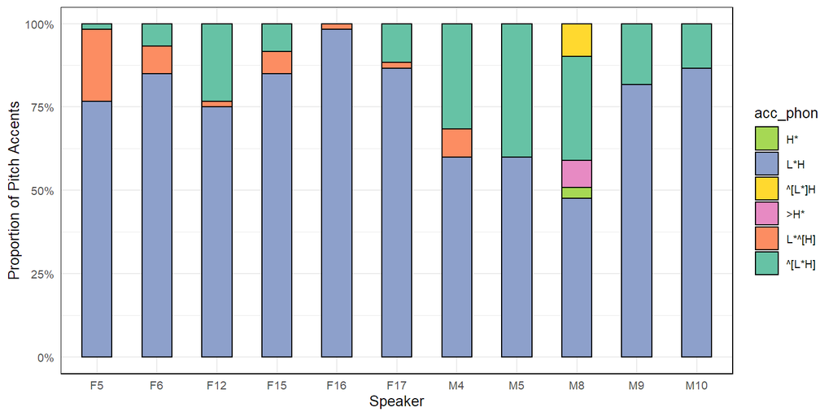

Distibution by mode of nuclear pitch accents in M-corpus (adjusted)

| mode | H* | >H* | ^[L*]H | L*H | L*^[H] | ^[L*H] |
| --- | --- | --- | --- | --- | --- | --- |
| MDC | 2 | 2 | 0 | 162 | 0 | 0 |
| MWH | 0 | 0 | 0 | 165 | 0 | 0 |
| MYN | 0 | 2 | 3 | 117 | 5 | 38 |
| MDQ | 0 | 1 | 3 | 62 | 25 | 74 |
| Total | 2 | 5 | 6 | 506 | 30 | 112 |

Distibution by of pitch accents by mode in M-corpus (adjusted, outliers excluded)

| mode | L*H | L*^[H] | ^[L*H] |
| --- | --- | --- | --- |
| MDC | 162 | 0 | 0 |
| MWH | 165 | 0 | 0 |
| MYN | 117 | 5 | 38 |
| MDQ | 62 | 25 | 74 |
| Total | 506 | 30 | 112 |

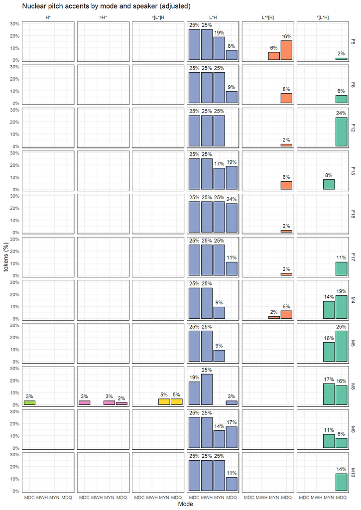

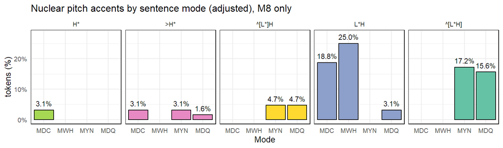

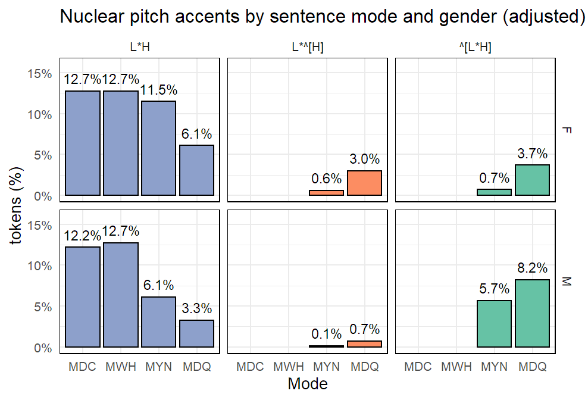

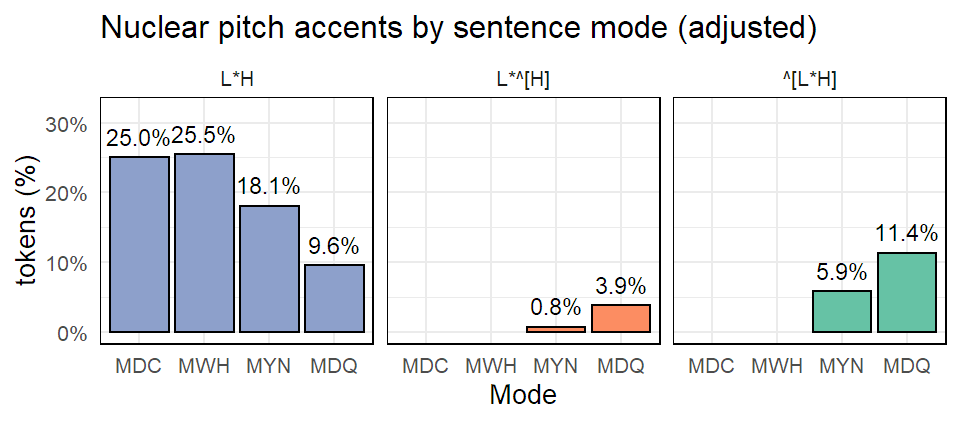

#### **GLMM test of nuclear H register as a fn of mode**

- **Complete separation issue**
- GLMER cannot correctly estimate the CIs of H:L for MDC and MWH since there are no instances of H for either level, leading to a problem know as “complete separation”. (The odds ratio for L is 1:0 against and for H it is 0:1 for, making the probability 0 but the CIs stretch from 0 to infinity.)

To resolve this issue, I have used the blme package, which uses “Maximum a posteriori estimation for linear and generalized linear mixed-effects models in a Bayesian setting” (documentation).

We can use this to “impose zero-mean Normal priors on the fixed effects (a 4 × 4 diagonal matrix with diagonal elements equal to 9, for variances of 9 or standard deviations of 3)”

With multivariate fixed effects, I just used normal() without spec

(http://bbolker.github.io/mixedmodels-misc/ecostats_chap.html#digression-complete-separation)

(directed from https://bbolker.github.io/mixedmodels-misc/glmmFAQ.html#penalizationhandling-complete-separation)`

```
## Cov prior  : speaker ~ wishart(df = 3.5, scale = Inf, posterior.scale = cov, common.scale = TRUE)
##            : prompt ~ wishart(df = 3.5, scale = Inf, posterior.scale = cov, common.scale = TRUE)
## Fixef prior: normal(sd = c(10, 2.5, ...), corr = c(0 ...), common.scale = FALSE)
## Prior dev  : 33.7783
##
## Generalized linear mixed model fit by maximum likelihood (Laplace
##   Approximation) [bglmerMod]
##  Family: binomial  ( logit )
## Formula: `high register in nucleus` ~ mode + gender + (1 | speaker) +
##     (1 | prompt)
##    Data: m_corpus_h_reg
##
##      AIC      BIC   logLik deviance df.resid
##    338.2    369.4   -162.1    324.2      632
##
## Scaled residuals:
##     Min      1Q  Median      3Q     Max
## -3.8269 -0.1790 -0.0447 -0.0150  3.0599
##
## Random effects:
##  Groups  Name        Variance Std.Dev.
##  speaker (Intercept) 1.5153   1.2310
##  prompt  (Intercept) 0.1848   0.4299
## Number of obs: 639, groups:  speaker, 11; prompt, 3
##
## Fixed effects:
##             Estimate Std. Error z value Pr(>|z|)
## (Intercept)  -6.3897     0.9530  -6.705 2.01e-11 ***
## modeMWH      -1.7054     1.5901  -1.072   0.2835
## modeMYN       4.2431     0.7605   5.579 2.42e-08 ***
## modeMDQ       6.3876     0.7866   8.121 4.64e-16 ***
## genderM       1.6990     0.7697   2.207   0.0273 *
## ---
## Signif. codes:  0 '***' 0.001 '**' 0.01 '*' 0.05 '.' 0.1 ' ' 1
##
## Correlation of Fixed Effects:
##         (Intr) modMWH modMYN modMDQ
## modeMWH -0.216
## modeMYN -0.759  0.273
## modeMDQ -0.783  0.261  0.915
## genderM -0.406 -0.004  0.024  0.070
```

isSingular(h_reg_model, tol=1e-5) –> FALSE

ANOVA of model and null model, register tier analysis

|  | npar | AIC | BIC | logLik | deviance | Chisq | Df | Pr(>Chisq) |
| --- | --- | --- | --- | --- | --- | --- | --- | --- |
| h_reg_model_null | 2 | 649.8735 | 658.7933 | -322.9367 | 645.8735 | NA | NA | NA |
| h_reg_model | 7 | 338.2115 | 369.4308 | -162.1057 | 324.2115 | 321.662 | 5 | 2.197584e-67 |

Conditional and marginal R<sup>2</sup> of model

| R2_conditional | R2_marginal |
| --- | --- |
| 0.79 | 0.69 |

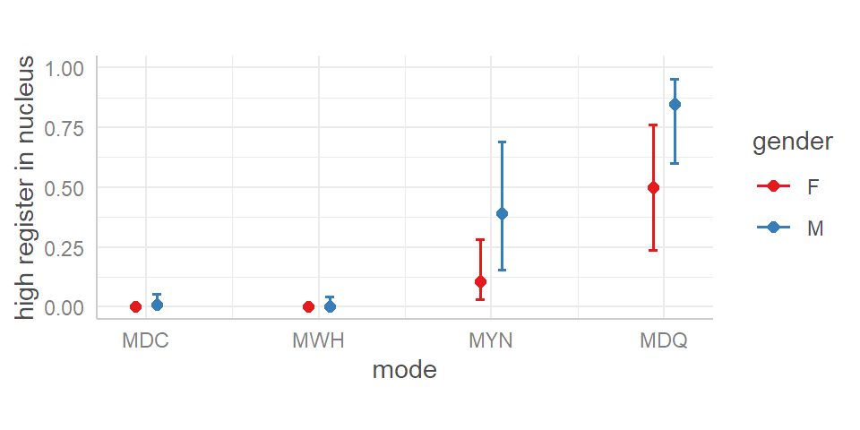

Conditional and marginal R<sup>2</sup> of model

| R2_conditional | R2_marginal |
| --- | --- |
| 0.79 | 0.69 |

summary of model: high register in nucleus ~ mode + gender + (1 | speaker) + (1 | prompt)

| term | estimate | conf.low | conf.high | std.error | z.value | p.value |
| --- | --- | --- | --- | --- | --- | --- |
| (Intercept) | -6.39 | -8.258 | -4.522 | 0.953 | -6.705 | 2.0e-11 |
| modeMWH | -1.705 | -4.822 | 1.411 | 1.590 | -1.072 | 0.2835 |
| modeMYN | 4.243 | 2.752 | 5.734 | 0.761 | 5.579 | 2.4e-08 |
| modeMDQ | 6.388 | 4.846 | 7.929 | 0.787 | 8.121 | 4.6e-16 |
| genderM | 1.699 | 0.19 | 3.208 | 0.770 | 2.207 | 0.0273 |

b0 for high register in nucleus ~ mode + gender + (1 | speaker) + (1 | prompt) , register tier analysis

| intercept | estimate | conf.low | conf.high | std.error | z.value | p.value |
| --- | --- | --- | --- | --- | --- | --- |
| modeMDC | -6.39 | -8.508 | -4.271 | 1.081 | -5.912 | 3.4e-09 |
| modeMWH | -6.38 | -8.501 | -4.259 | 1.082 | -5.896 | 3.7e-09 |
| modeMYN | -2.205 | -3.464 | -0.946 | 0.642 | -3.432 | 6.0e-04 |
| modeMDQ | -0.069 | -1.222 | 1.083 | 0.588 | -0.118 | 0.906 |

b1 for high register in nucleus ~ mode + gender + (1 | speaker) + (1 | prompt) , register tier analysis

| intercept | slope | estimate | conf.low | conf.high | std.error | z.value | p.value |
| --- | --- | --- | --- | --- | --- | --- | --- |
| modeMDC | modeMWH | -1.705 | -6.037 | 2.627 | 2.210 | -0.772 | 0.44 |
| modeMDC | modeMYN | 4.243 | 2.47 | 6.016 | 0.905 | 4.691 | 2.7e-06 |
| modeMDC | modeMDQ | 6.388 | 4.571 | 8.204 | 0.927 | 6.891 | 5.5e-12 |
| modeMWH | modeMYN | 4.233 | 2.458 | 6.009 | 0.906 | 4.673 | 3.0e-06 |
| modeMWH | modeMDQ | 6.378 | 4.559 | 8.197 | 0.928 | 6.871 | 6.4e-12 |
| modeMYN | modeMDQ | 2.213 | 1.585 | 2.84 | 0.320 | 6.910 | 4.9e-12 |
| intercept | genderM | 1.699 | 0.116 | 3.282 | 0.808 | 2.104 | 0.035 |

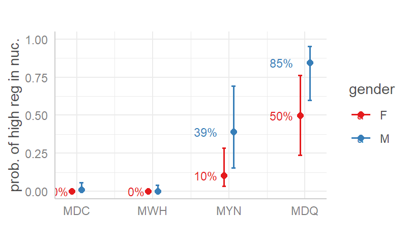

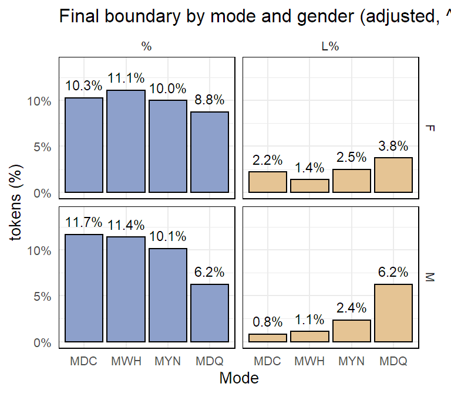

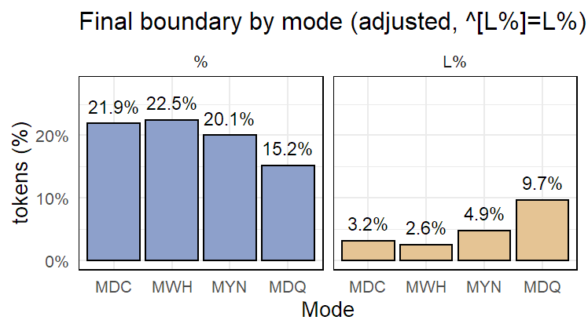

#### **GLMM test of boundary as a fn of mode**

- Random intercepts only since models with random slopes generate singularity issues.

```
## Cov prior  : speaker ~ wishart(df = 3.5, scale = Inf, posterior.scale = cov, common.scale = TRUE)
##            : prompt ~ wishart(df = 3.5, scale = Inf, posterior.scale = cov, common.scale = TRUE)
## Prior dev  : -4.5084
##
## Generalized linear mixed model fit by maximum likelihood (Laplace
##   Approximation) [bglmerMod]
##  Family: binomial  ( logit )
## Formula: `L% boundary` ~ mode + gender + (1 | speaker) + (1 | prompt)
##    Data: m_corpus_boundaries
## Control:
## glmerControl(optimizer = "optimx", calc.derivs = FALSE, optCtrl = list(method = "nlminb",
##     starttests = FALSE, kkt = FALSE))
##
##      AIC      BIC   logLik deviance df.resid
##    424.9    456.1   -205.4    410.9      632
##
## Scaled residuals:
##     Min      1Q  Median      3Q     Max
## -3.7394 -0.3245 -0.1098 -0.0274  4.1437
##
## Random effects:
##  Groups  Name        Variance Std.Dev.
##  speaker (Intercept) 9.403    3.066
##  prompt  (Intercept) 2.148    1.466
## Number of obs: 639, groups:  speaker, 11; prompt, 3
##
## Fixed effects:
##             Estimate Std. Error z value Pr(>|z|)
## (Intercept)  -3.5112     1.5701  -2.236   0.0253 *
## modeMWH      -0.4147     0.4035  -1.028   0.3041
## modeMYN       0.6048     0.3725   1.623   0.1045
## modeMDQ       2.3111     0.3887   5.946 2.75e-09 ***
## genderM      -0.4412     1.9455  -0.227   0.8206
## ---
## Signif. codes:  0 '***' 0.001 '**' 0.01 '*' 0.05 '.' 0.1 ' ' 1
##
## Correlation of Fixed Effects:
##         (Intr) modMWH modMYN modMDQ
## modeMWH -0.113
## modeMYN -0.135  0.491
## modeMDQ -0.172  0.458  0.541
## genderM -0.547  0.000  0.000  0.013
```

isSingular(fin_phon_model, tol=1e-5) –> FALSE

ANOVA of model and null model, register tier analysis

|  | npar | AIC | BIC | logLik | deviance | Chisq | Df | Pr(>Chisq) |
| --- | --- | --- | --- | --- | --- | --- | --- | --- |
| fin_phon_model_null | 3 | 479.7317 | 493.1114 | -236.8658 | 473.7317 | NA | NA | NA |
| fin_phon_model | 7 | 424.8920 | 456.1113 | -205.4460 | 410.8920 | 62.8397 | 4 | 7.334043e-13 |

Conditional and marginal R<sup>2</sup> of model

| R2_conditional | R2_marginal |
| --- | --- |
| 0.79 | 0.07 |

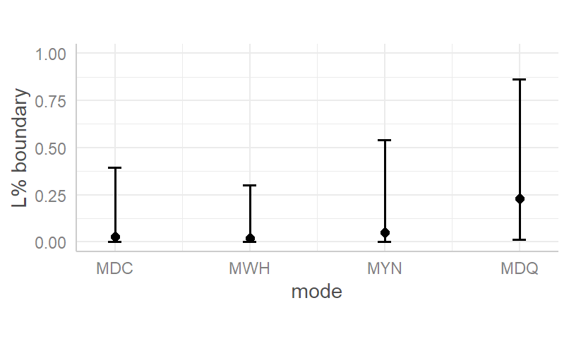

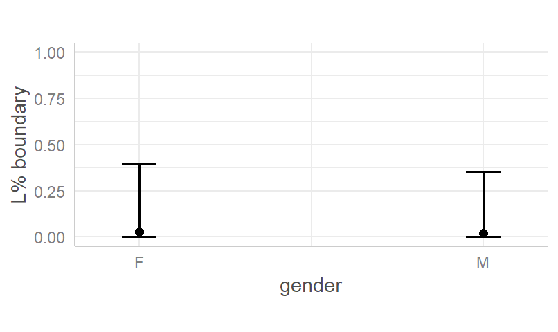

Conditional and marginal R<sup>2</sup> of model

| R2_conditional | R2_marginal |
| --- | --- |
| 0.79 | 0.07 |

summary of model: L% boundary ~ mode + gender + (1 | speaker) + (1 | prompt)

| term | estimate | conf.low | conf.high | std.error | z.value | p.value |
| --- | --- | --- | --- | --- | --- | --- |
| (Intercept) | -3.511 | -6.588 | -0.434 | 1.570 | -2.236 | 0.0253 |
| modeMWH | -0.415 | -1.206 | 0.376 | 0.404 | -1.028 | 0.3041 |
| modeMYN | 0.605 | -0.125 | 1.335 | 0.373 | 1.623 | 0.1045 |
| modeMDQ | 2.311 | 1.549 | 3.073 | 0.389 | 5.946 | 2.8e-09 |
| genderM | -0.441 | -4.254 | 3.372 | 1.946 | -0.227 | 0.8206 |

b0 for L% boundary ~ mode + gender + (1 | speaker) + (1 | prompt) , register tier analysis

| intercept | estimate | conf.low | conf.high | std.error | z.value | p.value |
| --- | --- | --- | --- | --- | --- | --- |
| modeMDC | -3.511 | -6.588 | -0.434 | 1.570 | -2.236 | 0.025 |
| modeMWH | -3.926 | -7.015 | -0.837 | 1.576 | -2.491 | 0.013 |
| modeMYN | -2.906 | -5.972 | 0.159 | 1.564 | -1.859 | 0.063 |
| modeMDQ | -1.2 | -4.24 | 1.84 | 1.551 | -0.774 | 0.439 |

b1 for L% boundary ~ mode + gender + (1 | speaker) + (1 | prompt) , register tier analysis

| intercept | slope | estimate | conf.low | conf.high | std.error | z.value | p.value |
| --- | --- | --- | --- | --- | --- | --- | --- |
| modeMDC | modeMWH | -0.415 | -1.206 | 0.376 | 0.404 | -1.028 | 0.304 |
| modeMDC | modeMYN | 0.605 | -0.125 | 1.335 | 0.373 | 1.623 | 0.104 |
| modeMDC | modeMDQ | 2.311 | 1.549 | 3.073 | 0.389 | 5.946 | 2.8e-09 |
| modeMWH | modeMYN | 1.02 | 0.25 | 1.789 | 0.393 | 2.597 | 0.009 |
| modeMWH | modeMDQ | 2.726 | 1.917 | 3.535 | 0.413 | 6.604 | 4.0e-11 |
| modeMYN | modeMDQ | 1.706 | 0.991 | 2.421 | 0.365 | 4.677 | 2.9e-06 |
| intercept | genderM | -0.441 | -4.254 | 3.372 | 1.946 | -0.227 | 0.821 |

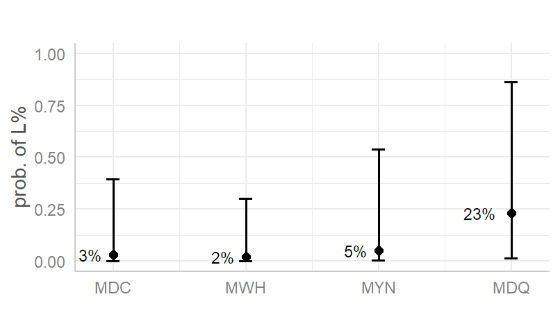

probability of L%

| mode | predicted | conf.low | conf.high | std.error |
| --- | --- | --- | --- | --- |
| MDC | 2.9% | 0.1% | 39.3% | 1.570 |
| MWH | 1.9% | 0.1% | 30.2% | 1.576 |
| MYN | 5.2% | 0.3% | 54.0% | 1.564 |
| MDQ | 23.1% | 1.4% | 86.3% | 1.551 |